# ITM 818 Data Management and Visualization

Data Visualization and Modeling in R

```r
#Imports
library(ggplot2)
library(dplyr)
library(tidyr)
library(gridExtra)
library(boot)
library(leaps)
```

Part I.

Used car auctions. One of the biggest challenges of an auto dealership purchasing a used car at an auto auction is the risk that the vehicle might have serious issues that prevent it from being sold to customers. The auto community calls these unfortunate purchases “kicks.” Kicked cars often result when there are tampered odometers, mechanical issues the dealer is not able to address, issues with getting the vehicle title from the seller, or some other unforeseen problem. Kicked cars can be very costly to dealers for transportation cost, throw-away repair work, and market losses in reselling the vehicle. Modelers who can figure out which cars have a higher risk of being kicked can provide real value to dealerships trying to provide the best inventory selection possible to their customers. The goal of this problem is to predict if the car purchased at the auction is a Kick (bad buy). Dataset: please find the CSV dataset and the Excel data dictionary. Each observation is a transaction.

IsBadBuy is the response variable.

Please use R (any packages such as ggplot2 and boot, etc.) to answer the following questions. (30 points)

```r
kickedCars <- read.csv("/Users/nidhi/Desktop/temp-github/usedCarsAuction/kickedCars.csv", header=TRUE)
View(kickedCars)
cars = kickedCars
```

1. Do the proportions of vehicle sizes differ across American manufacturers? Which American manufacturers prefer van (in terms of percentage)? Please develop a single visualization to demonstrate the answer. (5 points)

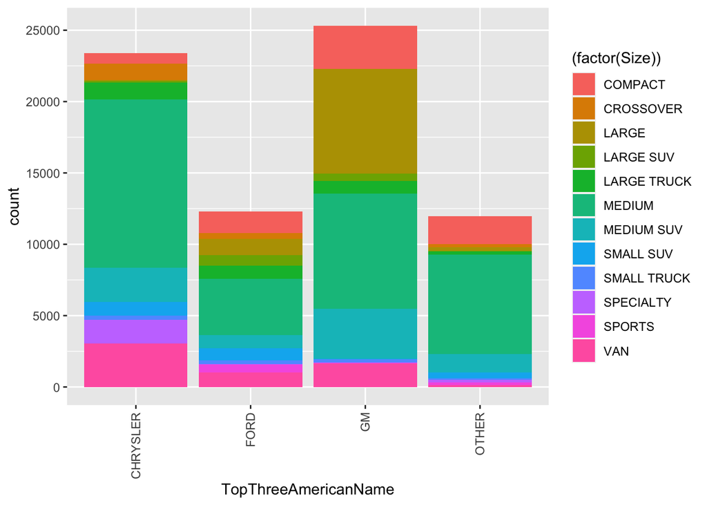

```r
ggplot(data=cars)+
  geom_bar(mapping=aes(x=TopThreeAmericanName,fill=(factor(Size)),position="fill"))+
  scale_color_brewer(palette="Paired")+
  theme(axis.text.x = element_text(angle = 90, hjust =1, vjust = 0.5))
```

From the graph, it is clear that the count is largest for CRYSLER, and hence they prefer Van more than other manufacturer.

2. Compare the distributional density of continuous attribute odometer across different nationalities. Are the distributions very different from each other? (5 points)

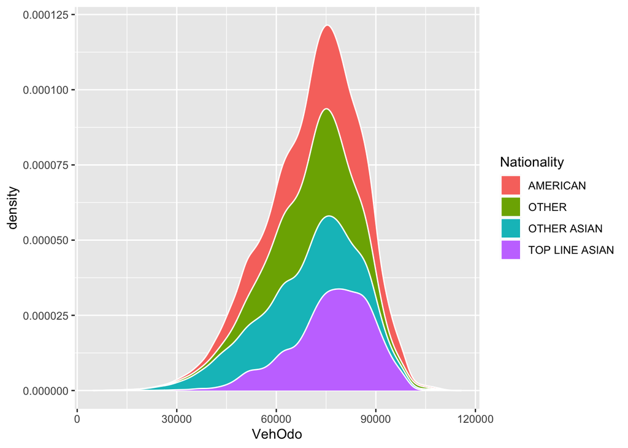

```r
ggplot(data=cars)+geom_density(mapping=aes(x=VehOdo,fill=Nationality),color="white",position="stack")
```

3. Use a stacked bar chart to show the total number of “bad buys” for each manufacturer and year. List the top 3 manufacturers that have the largest total number of bad buys. (Hint: notice that it is total number of transactions that are “bad buy,” not the total number of transactions.) (5 points)

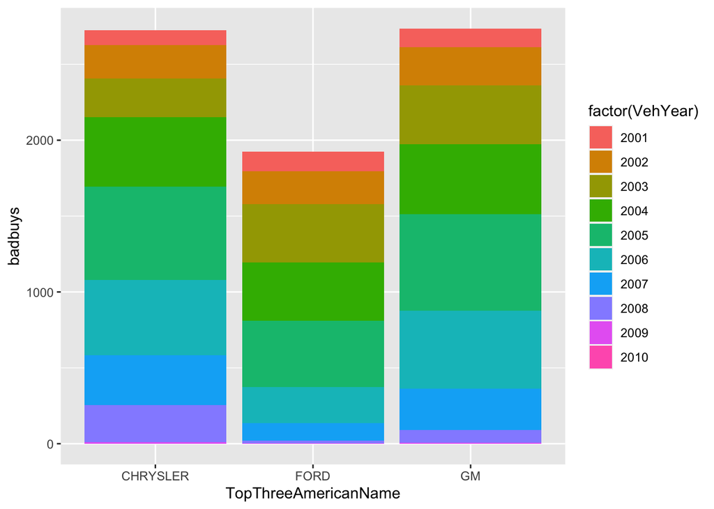

```r
bad_buys = cars %>%
          group_by(TopThreeAmericanName,VehYear)%>%
          summarise(badbuys = sum(IsBadBuy)) %>%
          arrange(desc(badbuys))

#notice that bad_buys have Other as their least count -> so I'm removing it.
bad_buys=bad_buys[bad_buys$TopThreeAmericanName!='OTHER',]

ggplot(data=bad_buys,mapping=aes(x=TopThreeAmericanName, y = badbuys, fill=factor(VehYear)))+
  geom_bar(stat = "identity")
```

4. Use slide-by-slide boxplots show the distribution of “MMRCurrentRetailAveragePrice” for each vehicle year. Draw the same graph for “MMRCurrentRetailCleanPrice” as well. Comparing the two graphs, which group has higher average prices? Is this conclusion consistent for different years? Hint: vehicle year must be converted to a factor data. (5 points)

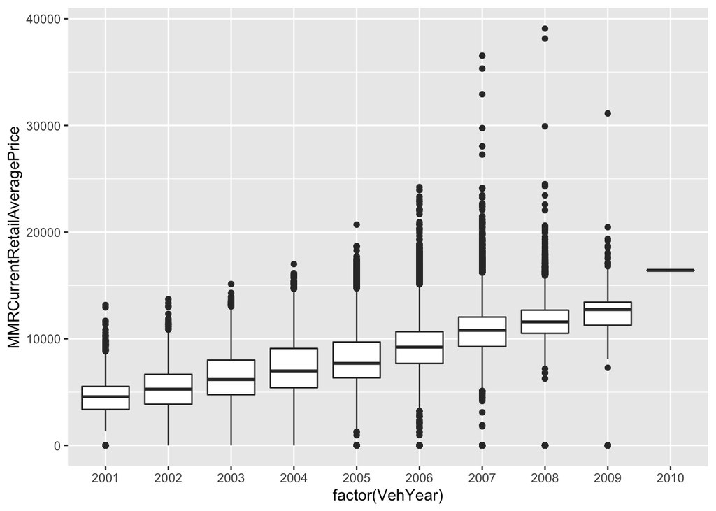

```r
ggplot(cars, aes(x=MMRCurrentRetailAveragePrice, y=factor(VehYear))) + geom_boxplot() +coord_flip()
```

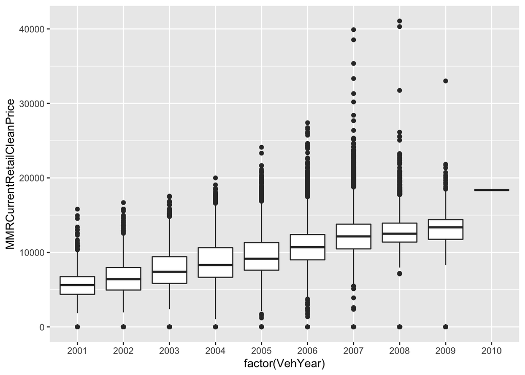

```r
ggplot(cars, aes(x=MMRCurrentRetailCleanPrice, y=factor(VehYear))) + geom_boxplot() +coord_flip()
```

You can see that the median shifts upwards when we compare the graph 1 and graph 2. This means that group: MMRCurrentRetailCleanPrice has a higher price range and it is consistent with all the years.

5. Focus on those car manufacturers that had more than 300 bad buys, and then show the “proportion of bad buy” for each manufacturer and vehicle year, but in a different visualization tool (do not use bar chart) Hint: use a chart for summary statistics. (5 points)

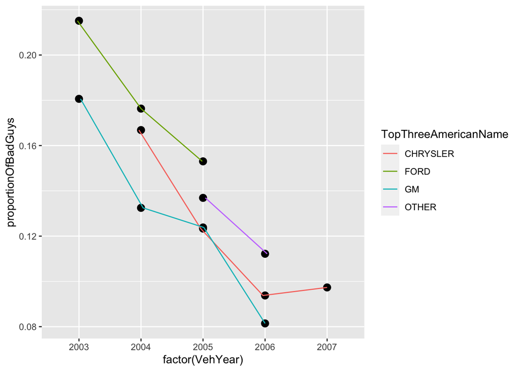

```r
bad_buys = cars %>%
          group_by(TopThreeAmericanName,VehYear)%>%
          summarise(badbuys = sum(IsBadBuy),count=n(),proportionOfBadGuys=badbuys/count)  %>%
          filter((badbuys)>300)


ggplot(bad_buys, aes(x= factor(VehYear), y = proportionOfBadGuys)) + geom_point(position=position_dodge(0.1),size=3)+
 geom_line(aes(group=TopThreeAmericanName,color=TopThreeAmericanName),position=position_dodge(0.1))
```

6. For vehicles of top three American manufactures (see attribute TopThreeAmericanName), what is the relationship between odometer and auction price of the vehicle in average condition at the time of purchase (MMRAcquisitionAuctionAveragePrice)? Is that relationship different depending on whether the transactions are “bad buys?” Please use a single scatter plot to show the relationship and create two “linear model” smoothed lines with confidence intervals (standard errors), one for “good buys” and one for “bad buys.” Hint: use a small point size, so that the scatter plot is easier to view. (5 points)

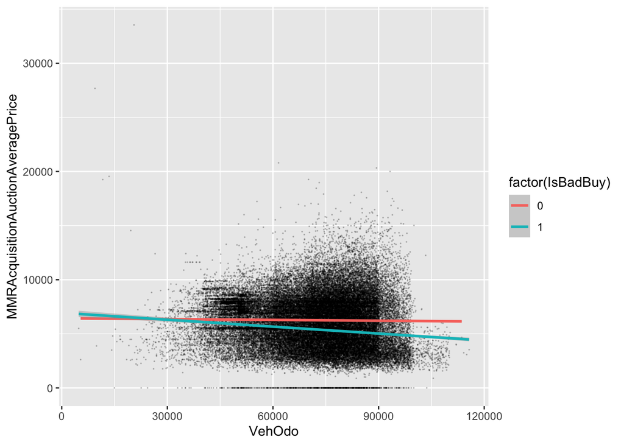

```r
cars1=cars[cars$TopThreeAmericanName!='OTHER',]

ggplot(data=cars1, aes(x=VehOdo,y=MMRAcquisitionAuctionAveragePrice)) +
  geom_point(alpha=0.2,size=0.0001)+
  geom_smooth(aes(color=factor(IsBadBuy)),method="lm",se=TRUE)
```

7. We then decide to use logistic regression to predict IsBadBuy using the following predictors: VehicleAge, TopThreeAmericanName, WheelType, VehOdo, Size, VehBCost, IsOnline, and WarrantyCost. Please apply the validation set approach to evaluate performance of the model in terms of accuracy, precision and recall. Hint: use sample() function to generate a vector of TRUE/FALSE with probabilities 0.7 and 0.3: train.index=sample(c(TRUE,FALSE),size=nrow(data),prob=c(0.7,0.3),replace=TRUE).

```r
train.index=sample(c(TRUE,FALSE),size=nrow(cars),prob=c(0.7,0.3),replace=TRUE)
# Create training set: training_set
train.data <- cars[train.index, ]
# Create test set: test_set
test.data <- cars[-train.index, ]


model1 = glm(IsBadBuy ~ VehicleAge+ as.factor(TopThreeAmericanName)+as.factor(WheelType)+ VehOdo+ as.factor(Size)+ VehBCost+ as.factor(IsOnlineSale)+ WarrantyCost,
             data = train.data, family = binomial(link="logit") )
summary(model1)
```

```
##
## Call:
## glm(formula = IsBadBuy ~ VehicleAge + as.factor(TopThreeAmericanName) +
##     as.factor(WheelType) + VehOdo + as.factor(Size) + VehBCost +
##     as.factor(IsOnlineSale) + WarrantyCost, family = binomial(link = "logit"),
##     data = train.data)
##
## Deviance Residuals:
##     Min       1Q   Median       3Q      Max
## -2.2716  -0.4820  -0.3879  -0.3075   3.5276
##
## Coefficients:
##                                        Estimate Std. Error z value Pr(>|z|)
## (Intercept)                          -3.123e+00  1.434e-01 -21.781  < 2e-16 ***
## VehicleAge                            2.271e-01  1.104e-02  20.575  < 2e-16 ***
## as.factor(TopThreeAmericanName)FORD  -1.095e-02  4.575e-02  -0.239 0.810931
## as.factor(TopThreeAmericanName)GM    -3.239e-01  4.291e-02  -7.547 4.47e-14 ***
## as.factor(TopThreeAmericanName)OTHER -2.575e-03  4.833e-02  -0.053 0.957506
## as.factor(WheelType)Covers           -1.210e-01  3.624e-02  -3.338 0.000844 ***
## as.factor(WheelType)NULL              3.165e+00  5.402e-02  58.587  < 2e-16 ***
## as.factor(WheelType)Special           9.694e-02  1.359e-01   0.713 0.475770
## VehOdo                                8.063e-06  1.201e-06   6.712 1.92e-11 ***
## as.factor(Size)CROSSOVER             -2.585e-01  1.226e-01  -2.109 0.034964 *
## as.factor(Size)LARGE                 -2.744e-01  7.524e-02  -3.647 0.000265 ***
## as.factor(Size)LARGE SUV              5.971e-02  1.250e-01   0.478 0.632761
## as.factor(Size)LARGE TRUCK           -2.695e-01  1.010e-01  -2.669 0.007604 **
## as.factor(Size)MEDIUM                -1.648e-01  5.129e-02  -3.214 0.001308 **
## as.factor(Size)MEDIUM SUV            -8.259e-04  7.466e-02  -0.011 0.991173
## as.factor(Size)SMALL SUV             -2.644e-01  9.889e-02  -2.673 0.007509 **
## as.factor(Size)SMALL TRUCK           -2.788e-01  1.355e-01  -2.058 0.039566 *
## as.factor(Size)SPECIALTY             -1.694e-01  1.286e-01  -1.317 0.187905
## as.factor(Size)SPORTS                 1.709e-04  1.410e-01   0.001 0.999033
## as.factor(Size)VAN                   -3.608e-01  8.018e-02  -4.500 6.80e-06 ***
## VehBCost                             -9.273e-05  1.309e-05  -7.086 1.38e-12 ***
## as.factor(IsOnlineSale)1             -6.790e-02  9.909e-02  -0.685 0.493184
## WarrantyCost                          1.443e-04  3.480e-05   4.148 3.36e-05 ***
## ---
## Signif. codes:  0 '***' 0.001 '**' 0.01 '*' 0.05 '.' 0.1 ' ' 1
##
## (Dispersion parameter for binomial family taken to be 1)
##
##     Null deviance: 38086  on 51146  degrees of freedom
## Residual deviance: 31968  on 51124  degrees of freedom
## AIC: 32014
##
## Number of Fisher Scoring iterations: 5
```

```r
test.data$prob=predict(model1,test.data,type="response")
test.data$pred=ifelse(test.data$prob>0.5,1,0)
confusion=table(actual=test.data$IsBadBuy,predicted=test.data$pred)
confusion
```

```
##       predicted
## actual     0     1
##      0 63113   888
##      1  6819  2157
```

```r
TP=confusion[1,1]
FN=confusion[1,2]
FP=confusion[2,1]
TN=confusion[2,2]
accuracy=(TP+TN)/nrow(test.data)
precision=TP/(TP+FP)
recall=TP/(TP+FN)
error=1-accuracy
data.frame(accuracy,precision,recall,error)
```

```
##    accuracy precision    recall     error
## 1 0.8943914  0.902491 0.9861252 0.1056086
```

We can see that the accuracy achieved by the model is 89.4%, which means the data predicts the Bad buy as a bad buy and Good buy as a good buy 89.4% of the time.

8. Finally, we apply a logistic regression model with the same set of predictors as (7), using 10-fold cross-validation to evaluate its predictive performance. Please calculate the cross-validation-based (average) accuracy, precision, and recall. Hint: use the “boot” package. (10 points)

```r
model2=glm(IsBadBuy ~ VehicleAge+ as.factor(TopThreeAmericanName)+as.factor(WheelType)+ VehOdo+ as.factor(Size)+ VehBCost+ as.factor(IsOnlineSale)+ WarrantyCost,
             data = train.data)

cost.error=function(r, pi = 0) mean(abs(r-pi)>0.5)
cv.error=boot::cv.glm(train.data,model2,cost=cost.error,K=10)

cost.accuracy=function(r, pi = 0) mean(abs(r-pi)<0.5)
cv.accuracy=boot::cv.glm(train.data,model2,cost=cost.accuracy,K=10)

cost.precision=function(r, pi = 0) {
  TP=sum((pi>0.5)&(r==1))
  FP=sum((pi>0.5)&(r==0))
  return(TP/(TP+FP))
}
cost.recall=function(r, pi = 0) {
  TP=sum((pi>0.5)&(r==1))
  FN=sum((pi<=0.5)&(r==1))
  return(TP/(TP+FN))
}
cv.precision=boot::cv.glm(train.data,model2,cost=cost.precision,K=10)
cv.recall=boot::cv.glm(train.data,model2,cost=cost.recall,K=10)

data.frame(accuracy = cv.accuracy$delta[1],recall = cv.recall$delta[1],precision = cv.precision$delta[1],error = cv.error$delta[1])
```

```
##    accuracy    recall precision     error
## 1 0.8955168 0.2518744 0.7098258 0.1044832
```

9. In question (7) and (8), we only add a subset of the predictors. Discuss the possibility of including additional predictors into the model. Which variables should or should not be included? Why? This is an open question; you should discuss at least three variables. (10 points)

I have considered 3 additional variables to my model - MMRAcquisitionAuctionAveragePrice, Nationality,Auction

```r
modelAll= glm(IsBadBuy ~VehicleAge+ as.factor(TopThreeAmericanName)+as.factor(WheelType)+ VehOdo+ as.factor(Size)+ VehBCost+ as.factor(IsOnlineSale)+ WarrantyCost + MMRAcquisitionAuctionAveragePrice + as.factor(Auction) +as.factor(Nationality) ,
             data = train.data, family = binomial(link="logit") )
summary(modelAll)
```

```
##
## Call:
## glm(formula = IsBadBuy ~ VehicleAge + as.factor(TopThreeAmericanName) +
##     as.factor(WheelType) + VehOdo + as.factor(Size) + VehBCost +
##     as.factor(IsOnlineSale) + WarrantyCost + MMRAcquisitionAuctionAveragePrice +
##     as.factor(Auction) + as.factor(Nationality), family = binomial(link = "logit"),
##     data = train.data)
##
## Deviance Residuals:
##     Min       1Q   Median       3Q      Max
## -2.3222  -0.4801  -0.3896  -0.3072   3.5115
##
## Coefficients: (1 not defined because of singularities)
##                                        Estimate Std. Error z value Pr(>|z|)
## (Intercept)                          -3.186e+00  1.554e-01 -20.504  < 2e-16 ***
## VehicleAge                            2.609e-01  1.440e-02  18.121  < 2e-16 ***
## as.factor(TopThreeAmericanName)FORD  -2.170e-02  4.582e-02  -0.474 0.635782
## as.factor(TopThreeAmericanName)GM    -3.268e-01  4.291e-02  -7.617 2.60e-14 ***
## as.factor(TopThreeAmericanName)OTHER -4.419e-02  7.849e-02  -0.563 0.573484
## as.factor(WheelType)Covers           -1.081e-01  3.643e-02  -2.968 0.002999 **
## as.factor(WheelType)NULL              3.190e+00  5.505e-02  57.957  < 2e-16 ***
## as.factor(WheelType)Special           9.780e-02  1.361e-01   0.719 0.472447
## VehOdo                                6.993e-06  1.247e-06   5.610 2.02e-08 ***
## as.factor(Size)CROSSOVER             -2.943e-01  1.242e-01  -2.369 0.017815 *
## as.factor(Size)LARGE                 -2.786e-01  7.585e-02  -3.673 0.000240 ***
## as.factor(Size)LARGE SUV              7.346e-03  1.283e-01   0.057 0.954339
## as.factor(Size)LARGE TRUCK           -3.032e-01  1.032e-01  -2.939 0.003291 **
## as.factor(Size)MEDIUM                -1.688e-01  5.183e-02  -3.256 0.001129 **
## as.factor(Size)MEDIUM SUV            -4.006e-02  7.717e-02  -0.519 0.603660
## as.factor(Size)SMALL SUV             -3.142e-01  1.012e-01  -3.104 0.001911 **
## as.factor(Size)SMALL TRUCK           -3.056e-01  1.362e-01  -2.244 0.024819 *
## as.factor(Size)SPECIALTY             -2.174e-01  1.310e-01  -1.659 0.097137 .
## as.factor(Size)SPORTS                -4.430e-02  1.429e-01  -0.310 0.756499
## as.factor(Size)VAN                   -3.639e-01  8.056e-02  -4.517 6.27e-06 ***
## VehBCost                             -1.355e-04  1.746e-05  -7.760 8.49e-15 ***
## as.factor(IsOnlineSale)1             -7.032e-02  9.918e-02  -0.709 0.478280
## WarrantyCost                          1.344e-04  3.530e-05   3.807 0.000141 ***
## MMRAcquisitionAuctionAveragePrice     5.532e-05  1.352e-05   4.093 4.25e-05 ***
## as.factor(Auction)MANHEIM            -3.027e-03  3.813e-02  -0.079 0.936720
## as.factor(Auction)OTHER              -1.187e-01  4.584e-02  -2.589 0.009632 **
## as.factor(Nationality)OTHER           1.346e-01  2.892e-01   0.465 0.641692
## as.factor(Nationality)OTHER ASIAN     3.726e-02  8.444e-02   0.441 0.659081
## as.factor(Nationality)TOP LINE ASIAN         NA         NA      NA       NA
## ---
## Signif. codes:  0 '***' 0.001 '**' 0.01 '*' 0.05 '.' 0.1 ' ' 1
##
## (Dispersion parameter for binomial family taken to be 1)
##
##     Null deviance: 38086  on 51146  degrees of freedom
## Residual deviance: 31941  on 51119  degrees of freedom
## AIC: 31997
##
## Number of Fisher Scoring iterations: 5
```

MMRAcquisitionAuctionAveragePrice, Nationality,Auction are the added new variables